# behavioral QC analyses

michael freund

2020-10-21

# 1 about

- list for each task*session for subjs or trials to exclude
- estimate behavioral effects

# 2 My notes from basecamp thread

- 161832 is one i’ve excluded from my analyses. high error rates in stroop (>10%, many omissions) in Bas and Pro, and in other tasks.
- DMCC3128324 axcpt 2nd run ~40% errors. would be one to check if they were indeed responding (or were asleep), motion levels, etc.
- 203418: 80% of the responses were incorrect in AXCPT. guessing this is a response-mapping issue (i.e., they got the buttons mixed up). if it were up to me i’d exclude bc it’s hard to verify what instructions they were following (and on which trials).
- 448347: generally high error rate; would be one to check whether they seem to be sleeping (they may just be bad at the tasks).
- 580650: axcpt run 2, 16% of frames censored (FD>0.9)
- DMCC1328342: stroop run 1, 10% frames censored, mean(FD) = 0.6
- 849971: cluster of stroop RTs that look like they may be due to that audio signal artifact. (right around 500 ms, very low variance, clear deviance in QQ plot). not suggesting tossing this subj, but just excluding those RT measurements.
- DMCC8260571

# 3 complete cases (subjects)

```
##  [1] "233326"      "352738"      "729254"      "843151"      "873968"
##  [6] "DMCC3204738" "DMCC4260551" "DMCC5009144" "DMCC6371570" "DMCC6661074"
## [11] "DMCC6904377" "DMCC6960387" "DMCC9953810" "171330"      "250427"
## [16] "DMCC1624043" "DMCC7297690" "DMCC8033964"
```

```
## [1] 18
```

```
##  [1] "107321"      "115825"      "123117"      "130114"      "130518"
##  [6] "132017"      "135730"      "138837"      "141422"      "150423"
## [11] "155938"      "158136"      "160830"      "161832"      "165032"
## [16] "173738"      "178243"      "178647"      "178950"      "182436"
## [21] "197449"      "203418"      "204319"      "300618"      "317332"
## [26] "346945"      "393550"      "448347"      "580650"      "594156"
## [31] "601127"      "672756"      "765864"      "814649"      "849971"
## [36] "877168"      "DMCC1328342" "DMCC1596165" "DMCC1971064" "DMCC2442951"
## [41] "DMCC2609759" "DMCC2803654" "DMCC2834766" "DMCC3062542" "DMCC3963378"
## [46] "DMCC4191255" "562345"      "DMCC5195268" "DMCC5775387" "DMCC6418065"
## [51] "DMCC6484785" "DMCC6627478" "DMCC6671683" "DMCC6705371" "DMCC6721369"
## [56] "DMCC7921988" "DMCC8050964" "DMCC8078683" "DMCC8214059" "DMCC8260571"
## [61] "DMCC9441378" "DMCC9478705"
```

```
## [1] 62
```

# 4 errors

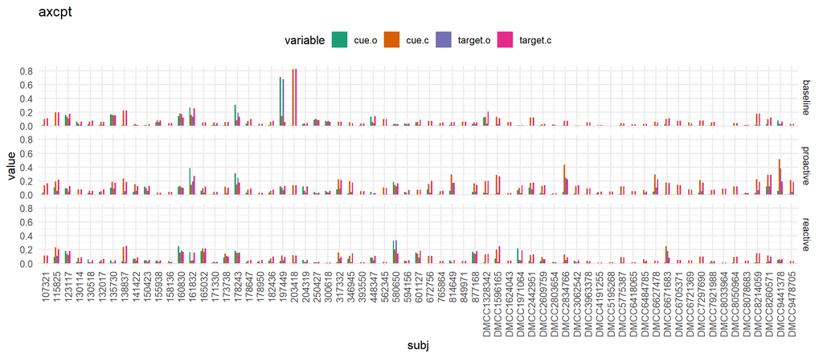

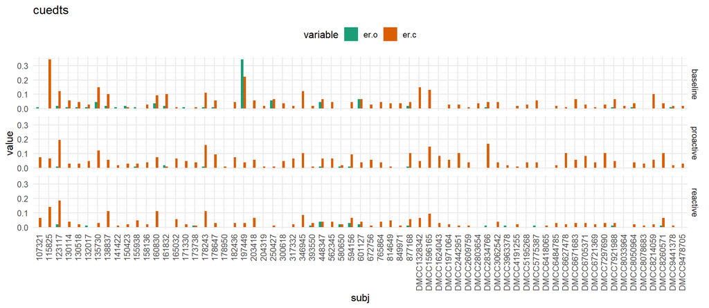

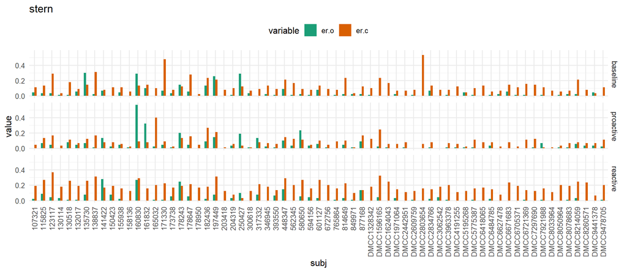

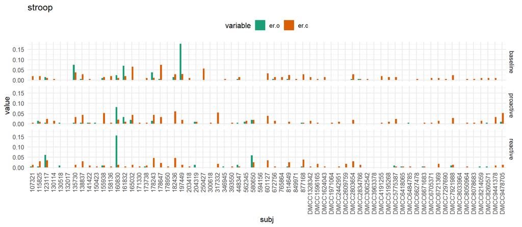

- 197449 has over 60 percent response omission in Axcpt baseline, on both the cue response and probe response. Their response omission in baseline is also the highest among all subjs all sessions for Stroop and Cuedts (>0.3 for cts, >0.15 for stroop).
- 203418 “flipped” response mappings in Axcpt baseline
- 160830 quite high Stroop reactive omission (>0.15)

## 4.1 summary stats

# 5 RT

## 5.1 initial models

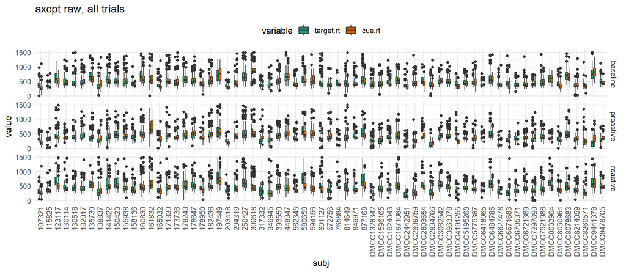

```
## [1] 199
```

```
## [1] 0.0184
```

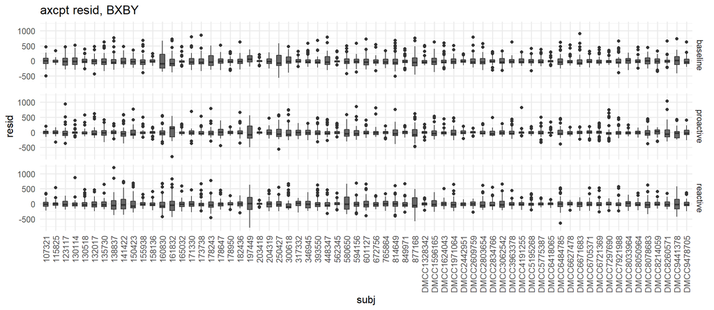

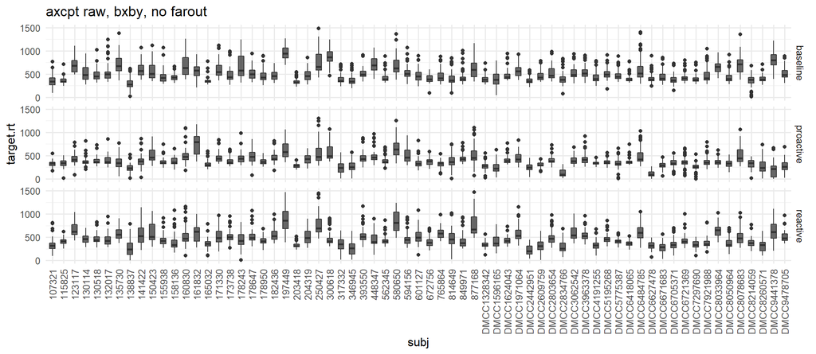

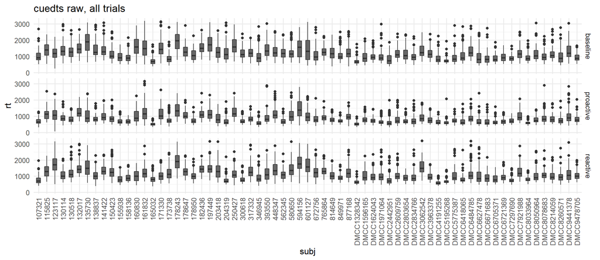

```
## [1] 45
```

```
## [1] 0.006679
```

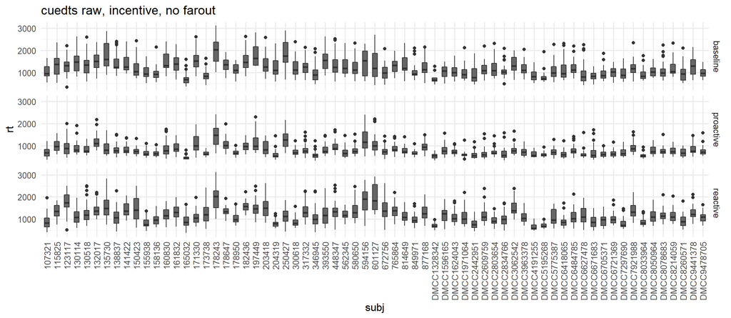

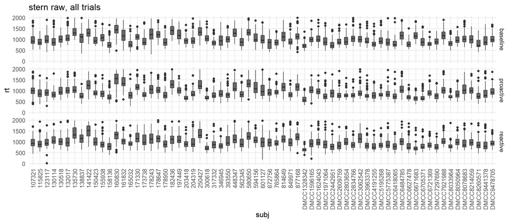

```
## [1] 11
```

```
## [1] 0.003663
```

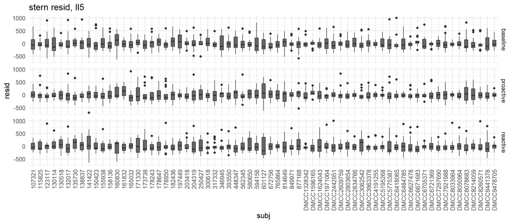

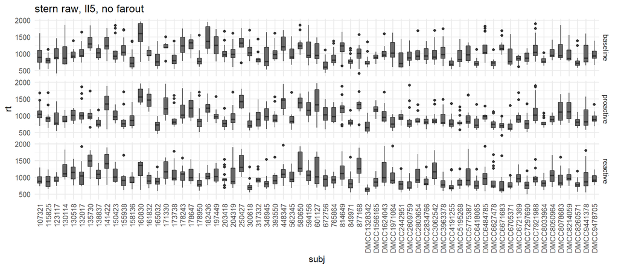

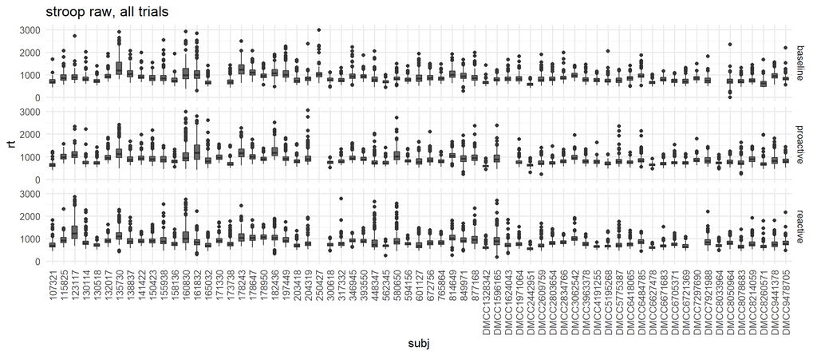

```
## [1] 393
```

```
## [1] 0.01621
```

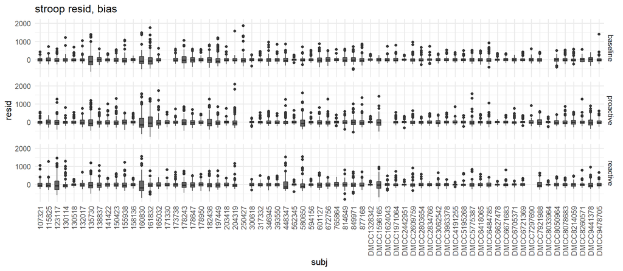

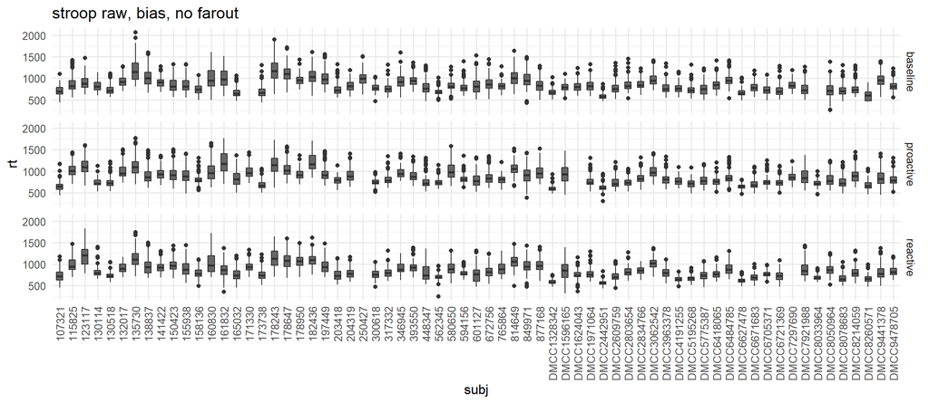

## 5.2 models on trimmed data

```
## $Axcpt
## Linear mixed model fit by REML. t-tests use Satterthwaite's method [
## lmerModLmerTest]
## Formula:
## target.rt ~ 0 + interaction(trial.type, session) + (0 + interaction(trial.type,
##     session) | subj)
##    Data: axcpt.rt.hilo[is.farout == FALSE]
## Control: lmerControl(optimizer = "bobyqa")
##
## REML criterion at convergence: 133056
##
## Scaled residuals:
##    Min     1Q Median     3Q    Max
## -3.738 -0.568 -0.110  0.449  3.930
##
## Random effects:
##  Groups   Name                                         Variance Std.Dev. Corr
##  subj     interaction(trial.type, session)BX.baseline  44899    211.9
##           interaction(trial.type, session)BY.baseline  15332    123.8    0.82
##           interaction(trial.type, session)BX.proactive 34761    186.4    0.71
##           interaction(trial.type, session)BY.proactive  9936     99.7    0.63
##           interaction(trial.type, session)BX.reactive  37890    194.7    0.79
##           interaction(trial.type, session)BY.reactive  16049    126.7    0.71
##  Residual                                              14858    121.9
##
##
##
##  0.61
##  0.62 0.92
##  0.71 0.76 0.69
##  0.74 0.65 0.72 0.86
##
## Number of obs: 10616, groups:  subj, 67
##
## Fixed effects:
##                                              Estimate Std. Error    df t value
## interaction(trial.type, session)BX.baseline     635.4       26.4  59.3    24.1
## interaction(trial.type, session)BY.baseline     482.7       15.3  62.6    31.5
## interaction(trial.type, session)BX.proactive    438.6       23.3  64.5    18.8
## interaction(trial.type, session)BY.proactive    371.3       12.4  64.9    30.0
```

[output cut: 262 more lines]

```
## intrctn(trl.typ,sssn)InCn.p 0.949
## intrctn(trl.typ,sssn)Cn.r   0.796
## intrctn(trl.typ,sssn)InCn.r 0.812
##                             intrctn(trl.typ,sssn)InCn.p
## intrctn(trl.typ,sssn)InCn.b
## intrctn(trl.typ,sssn)Cn.p
## intrctn(trl.typ,sssn)InCn.p
## intrctn(trl.typ,sssn)Cn.r   0.815
## intrctn(trl.typ,sssn)InCn.r 0.883
##                             intrctn(trl.typ,sssn)Cn.r
## intrctn(trl.typ,sssn)InCn.b
## intrctn(trl.typ,sssn)Cn.p
## intrctn(trl.typ,sssn)InCn.p
## intrctn(trl.typ,sssn)Cn.r
## intrctn(trl.typ,sssn)InCn.r 0.943
```

## 5.3 summary stats

# 6 cross-task correlations

## 6.1 summary stats

- numbers on upper triangle are rank correlation

### 6.1.1 RT

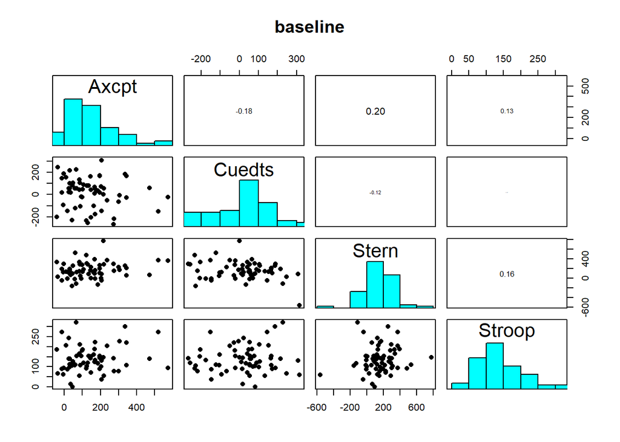

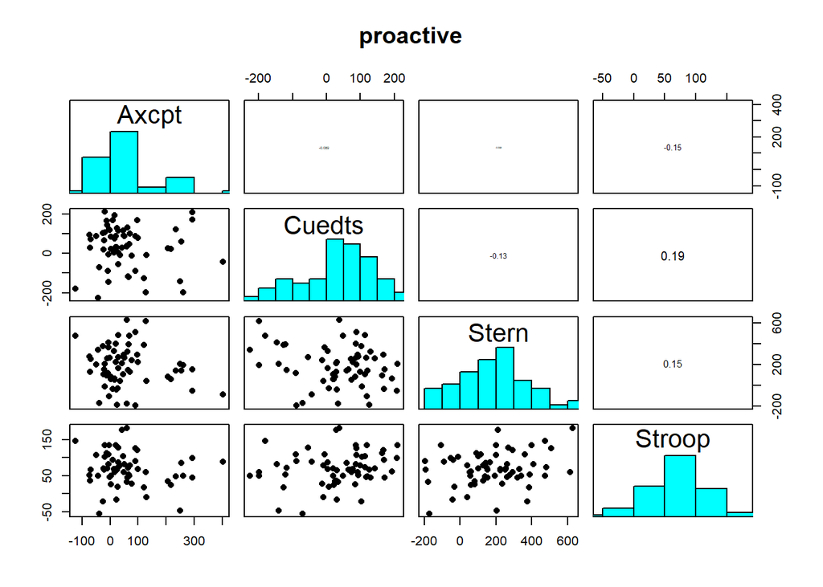

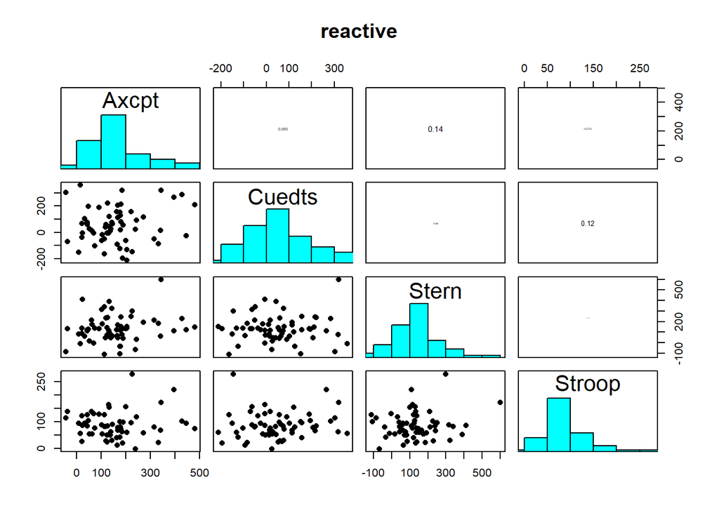

### 6.1.2 error

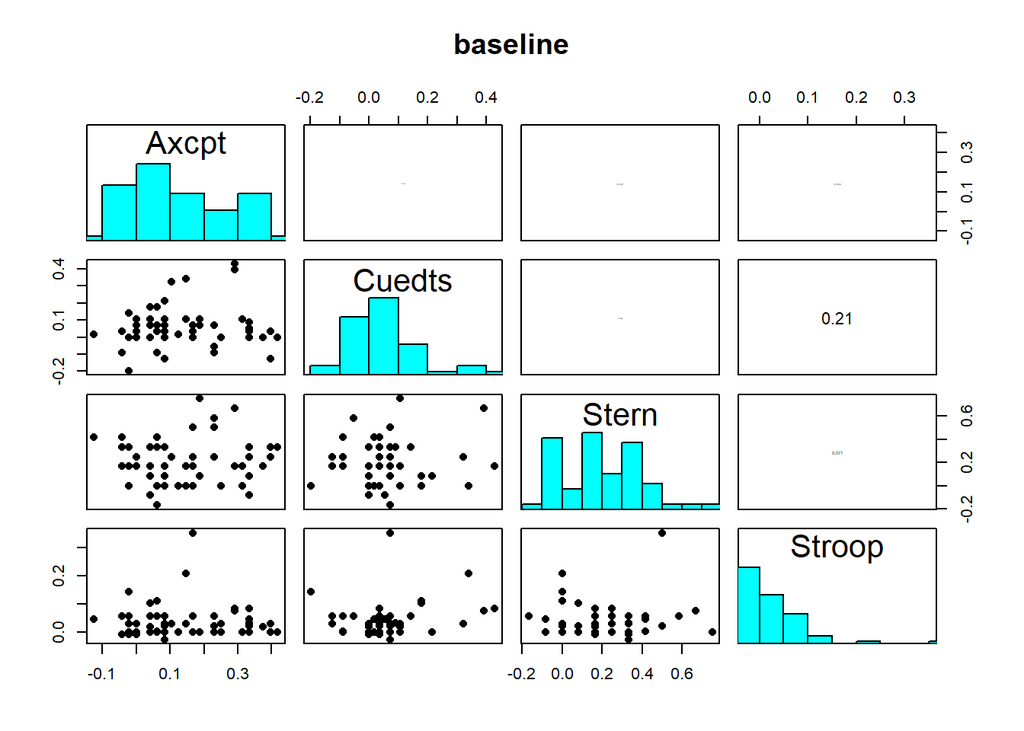

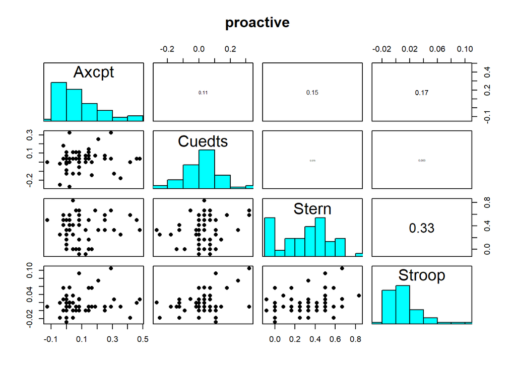

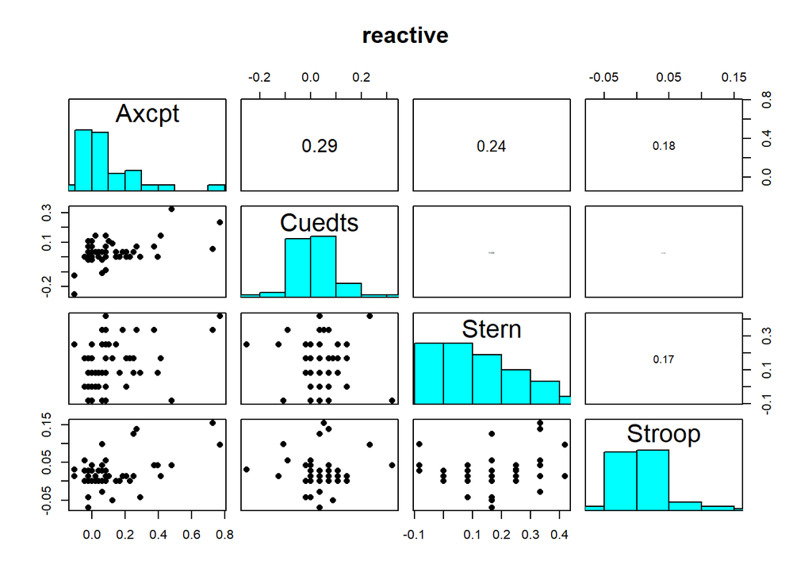

## 6.2 combined

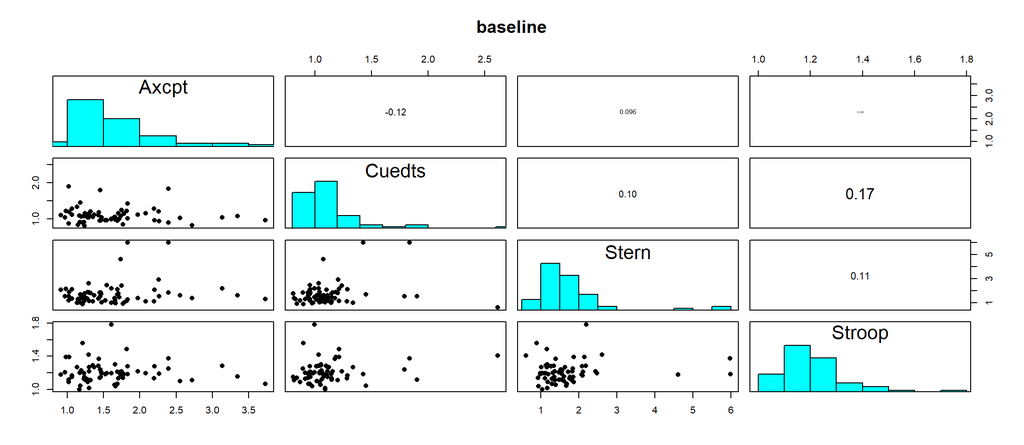

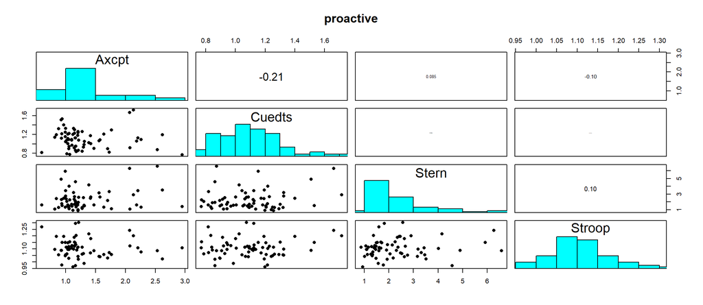

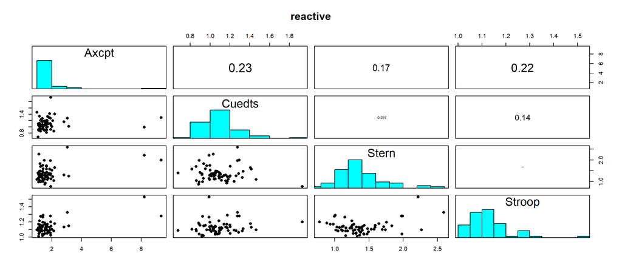

## 6.3 HLM

### 6.3.1 RT

### 6.3.2 error

# 7 write